# Web APIs

Pavan Akula

March 31, 2017

### DATA607-Week09 - Assignment

The purpose of this assignment is to connect to NYTimes.com website, extract information and store into R data frame for analysis. According to NYTimes.com developer [FAQ](http://developer.nytimes.com/faq) more API’s may be released over time. Following are the steps:

1. Get an API Key from the website http://developer.nytimes.com/signup.
2. Select an API to extract data.
3. Data extraction and storage.
4. Data analysis.

Libraries used

```r
library(urltools)
library(jsonlite)
library(knitr)
library(dplyr)
library(stringr)
library(ggplot2)
```

#### Get an API Key from the website

Open [NYTimes Create a New API Key](http://developer.nytimes.com/signup) web page and key in all the required information and click on [Create API Key.](http://developer.nytimes.com/signup) NYTimes will send an alpha-numeric key to the email address.

#### Select an API to extract data

Once API Key is acquired, validate it by visiting web page http://developer.nytimes.com/. Pick any topic of your choice and follow the instructions.

For the purpose of the assignment, I have picked two API’s “Most Popular API” and “Article Search API”.

##### Most Popular API

With the Most Popular API, you can get links and metadata for the blog posts and articles that are most frequently e-mailed, shared and viewed by NYTimes.com readers. Parameter accepted by this API are “section” and “time-period” Additional information can be found at http://developer.nytimes.com/most_popular_api_v2.json#/README.

Allowed values for the section:

- Arts
- Automobiles
- Blogs
- Books
- Business Day
- Education
- Fashion & Style
- Food
- Health
- Job Market
- Magazine
- membercenter
- Movies
- Multimedia
- N.Y.%20%2F%20Region
- NYT Now
- Obituaries
- Open
- Opinion
- Public Editor
- Real Estate
- Science
- Sports
- Style
- Sunday Review
- T Magazine
- Technology
- The Upshot
- Theater
- Times Insider
- Today’s Paper
- Travel
- U.S.
- World
- Your Money
- all-sections

Allowed values for time-period (represents days):

- 1
- 7
- 30

```r
#URL formation
#Base URL
nyt.base.url <- "https://api.nytimes.com/svc/mostpopular/v2/"

#Second part, path changes based on path, section, and time-period
#{mostemailed | mostshared | mostviewed}

#Possible paths
nyt.path <- data.frame(DisplayText=NA,UrlPath=NA)
nyt.path <- rbind(nyt.path, c("Most Emailed","mostemailed"))
nyt.path <- rbind(nyt.path, c("Most Shared","mostshared"))
nyt.path <- rbind(nyt.path, c("Most Viewed","mostviewed"))
nyt.path <- na.omit(nyt.path)

#Possible sections
nyt.sec<- c("Arts","Automobiles","Blogs","Books","Business Day","Education","Fashion & Style","Food","Health","Job Market","Magazine","membercenter","Movies","Multimedia","N.Y.%20%2F%20Region","NYT Now","Obituaries","Open","Opinion","Public Editor","Real Estate","Science","Sports","Style","Sunday Review","T Magazine","Technology","The Upshot","Theater","Times Insider","Today's Paper","Travel","U.S.","World","Your Money","all-sections")

#Possible time-period
nyt.time <- data.frame(DisplayText=NA,TimePath=NA)
nyt.time <- rbind(nyt.time, c("1 day","1.json"))
nyt.time <- rbind(nyt.time, c("7 days","7.json"))
nyt.time <- rbind(nyt.time, c("30 days","30.json"))
nyt.time <- na.omit(nyt.time)

nyt.path.data.frame <- data.frame(Path=NA,NYTUrl=NA)
#loop through path
for (p in 1:nrow(nyt.path)){
  #loop through sections
  for(s in 1:length(nyt.sec)){
    #loop through time
    for (t in 1:nrow(nyt.time)){

      # Generate complete URL
      nyt.complete.url <- paste0(nyt.base.url, nyt.path$UrlPath[p], "/", nyt.sec[s], "/", nyt.time$TimePath[t])

      #Attach API Key
      nyt.complete.url <- param_set(nyt.complete.url, key = "api-key", value = "a8a7bea8b95f4ef986e504ec99287013")

      nyt.complete.url <- URLencode(nyt.complete.url) #Converts spaces and special characters to URL format

      #Save the URL
      nyt.url.info <- paste0(nyt.path$DisplayText[p]," by ", nyt.sec[s], " in ", nyt.time$DisplayText[t])
      nyt.path.data.frame <- rbind(nyt.path.data.frame, c(nyt.url.info, nyt.complete.url))
    }
  }
}

nyt.path.data.frame <- na.omit(nyt.path.data.frame)
row.names(nyt.path.data.frame) <- NULL

set.seed(125)
nyt.path.data.sample <- nyt.path.data.frame %>% sample_n(., 10)
row.names(nyt.path.data.sample) <- NULL

kable(nyt.path.data.sample, format="pandoc", align="l", col.names = c("Path","NYTUrl"), row.names = NA,caption = "Sample list of URL's for *_NYTimes.com Most Popular API_*")
```

Sample list of URL’s for *NYTimes.com Most Popular API*

| Path | NYTUrl |
| --- | --- |
| Most Viewed by Open in 1 day | https://api.nytimes.com/svc/mostpopular/v2/mostviewed/Open/1.json?api-key=a8a7bea8b95f4ef986e504ec99287013 |
| Most Emailed by Movies in 7 days | https://api.nytimes.com/svc/mostpopular/v2/mostemailed/Movies/7.json?api-key=a8a7bea8b95f4ef986e504ec99287013 |
| Most Emailed by U.S. in 1 day | https://api.nytimes.com/svc/mostpopular/v2/mostemailed/U.S./1.json?api-key=a8a7bea8b95f4ef986e504ec99287013 |
| Most Shared by Blogs in 1 day | https://api.nytimes.com/svc/mostpopular/v2/mostshared/Blogs/1.json?api-key=a8a7bea8b95f4ef986e504ec99287013 |
| Most Viewed by Today’s Paper in 30 days | https://api.nytimes.com/svc/mostpopular/v2/mostviewed/Today's%20Paper/30.json?api-key=a8a7bea8b95f4ef986e504ec99287013 |
| Most Viewed by Your Money in 7 days | https://api.nytimes.com/svc/mostpopular/v2/mostviewed/Your%20Money/7.json?api-key=a8a7bea8b95f4ef986e504ec99287013 |
| Most Shared by Real Estate in 7 days | https://api.nytimes.com/svc/mostpopular/v2/mostshared/Real%20Estate/7.json?api-key=a8a7bea8b95f4ef986e504ec99287013 |
| Most Emailed by all-sections in 1 day | https://api.nytimes.com/svc/mostpopular/v2/mostemailed/all-sections/1.json?api-key=a8a7bea8b95f4ef986e504ec99287013 |
| Most Shared by U.S. in 30 days | https://api.nytimes.com/svc/mostpopular/v2/mostshared/U.S./30.json?api-key=a8a7bea8b95f4ef986e504ec99287013 |
| Most Shared by Theater in 7 days | https://api.nytimes.com/svc/mostpopular/v2/mostshared/Theater/7.json?api-key=a8a7bea8b95f4ef986e504ec99287013 |

##### Article Search API

You can get useful results from the Article Search API with a simple query. But you can also use filters and facets to extend the functionality of the API. Additional information on filters and sorting can be found at http://developer.nytimes.com/article_search_v2.json#/Documentation/GET/articlesearch.json.

```r
nyt.path.data.frame <- data.frame(Path=NA,NYTUrl=NA)
#URL formation
#Base URL
nyt.base.url <- "https://api.nytimes.com/svc/search/v2/articlesearch.json"

#Attach API Key
nyt.complete.url <- param_set(nyt.base.url, key = "api-key", value = "a8a7bea8b95f4ef986e504ec99287013")
nyt.complete.url <- URLencode(nyt.complete.url)
nyt.url.info <- "Generic Article Search"
nyt.path.data.frame <- rbind(nyt.path.data.frame, c(nyt.url.info, nyt.complete.url))

#Search query term. Search is performed on the article body, headline and byline looking for word apple.
nyt.complete.url <- param_set(nyt.base.url, key = "q", value = "Apple")
nyt.complete.url <- param_set(nyt.complete.url, key = "api-key", value = "a8a7bea8b95f4ef986e504ec99287013")
nyt.complete.url <- URLencode(nyt.complete.url)
nyt.url.info <- "Query Article Search with `q`"
nyt.path.data.frame <- rbind(nyt.path.data.frame, c(nyt.url.info, nyt.complete.url))

#The filter query results, search for word "Apple" and filter by "Court"
nyt.complete.url <- param_set(nyt.base.url, key = "q", value = "Apple")
nyt.complete.url <- param_set(nyt.complete.url, key = "fq", value = "Court")
nyt.complete.url <- param_set(nyt.complete.url, key = "api-key", value = "a8a7bea8b95f4ef986e504ec99287013")
nyt.complete.url <- URLencode(nyt.complete.url)
nyt.url.info <- "Filter Query results with `fq`"
nyt.path.data.frame <- rbind(nyt.path.data.frame, c(nyt.url.info, nyt.complete.url))

#Add date conditions Format: YYYYMMDD
nyt.complete.url <- param_set(nyt.base.url, key = "q", value = "Apple")
nyt.complete.url <- param_set(nyt.complete.url, key = "fq", value = "Court")
nyt.complete.url <- param_set(nyt.complete.url, key = "begin_date", value = "20160101")
nyt.complete.url <- param_set(nyt.complete.url, key = "end_date", value = "20160131")
nyt.complete.url <- param_set(nyt.complete.url, key = "api-key", value = "a8a7bea8b95f4ef986e504ec99287013")
nyt.complete.url <- URLencode(nyt.complete.url)
nyt.url.info <- "Filter Query results with `begin_date` and `end_date` `Format: YYYYMMDD`"
nyt.path.data.frame <- rbind(nyt.path.data.frame, c(nyt.url.info, nyt.complete.url))

#Sorting data
nyt.complete.url <- param_set(nyt.base.url, key = "q", value = "Apple")
nyt.complete.url <- param_set(nyt.complete.url, key = "fq", value = "Court")
nyt.complete.url <- param_set(nyt.complete.url, key = "begin_date", value = "20160101")
nyt.complete.url <- param_set(nyt.complete.url, key = "end_date", value = "20160131")
nyt.complete.url <- param_set(nyt.complete.url, key = "sort", value = "newest")
nyt.complete.url <- param_set(nyt.complete.url, key = "api-key", value = "a8a7bea8b95f4ef986e504ec99287013")
nyt.complete.url <- URLencode(nyt.complete.url)
nyt.url.info <- "Sort Query results with `sort` `newest or oldest`"
nyt.path.data.frame <- rbind(nyt.path.data.frame, c(nyt.url.info, nyt.complete.url))

nyt.path.data.frame <- na.omit(nyt.path.data.frame)
row.names(nyt.path.data.frame) <- NULL

kable(nyt.path.data.frame, format="pandoc", align="l", col.names = c("Path","NYTUrl"), row.names = NA,caption = "Sample list of URL's for *_NYTimes.com Article Search API_*")
```

Sample list of URL’s for *NYTimes.com Article Search API*

| Path | NYTUrl |
| --- | --- |
| Generic Article Search | https://api.nytimes.com/svc/search/v2/articlesearch.json?api-key=a8a7bea8b95f4ef986e504ec99287013 |
| Query Article Search with `q` | https://api.nytimes.com/svc/search/v2/articlesearch.json?q=Apple&api-key=a8a7bea8b95f4ef986e504ec99287013 |
| Filter Query results with `fq` | https://api.nytimes.com/svc/search/v2/articlesearch.json?q=Apple&fq=Court&api-key=a8a7bea8b95f4ef986e504ec99287013 |
| Filter Query results with `begin_date` and `end_date` `Format: YYYYMMDD` | https://api.nytimes.com/svc/search/v2/articlesearch.json?q=Apple&fq=Court&begin_date=20160101&end_date=20160131&api-key=a8a7bea8b95f4ef986e504ec99287013 |
| Sort Query results with `sort` `newest or oldest` | https://api.nytimes.com/svc/search/v2/articlesearch.json?q=Apple&fq=Court&begin_date=20160101&end_date=20160131&sort=newest&api-key=a8a7bea8b95f4ef986e504ec99287013 |

#### Data extraction and storage

Following code extracts JSON data using *Most Popular API* and stores into R data frames namely `mostemailed.data`, `mostshared.data` and `mostviewed.data`.

```r
#Extracting data using Most Popular API for World 7 days path
most<-c("mostemailed","mostshared","mostviewed")
nyt.base.url <- "https://api.nytimes.com/svc/mostpopular/v2/mostpath/World/7.json"

for (i in 1:length(most)){
  #First set of results
  nyt.complete.url <- str_replace(nyt.base.url, pattern = "mostpath", replacement = most[i])
  nyt.complete.url <- param_set(nyt.complete.url, key = "api-key", value = "a8a7bea8b95f4ef986e504ec99287013")
  nyt.complete.url <- URLencode(nyt.complete.url)
  nyt.raw.data <- fromJSON(nyt.complete.url)

  if (i==1){
    mostemailed.data <- nyt.raw.data$results
  }
  else if(i==2){
    mostshared.data <- nyt.raw.data$results
  }
  else{
    mostviewed.data <- nyt.raw.data$results
  }
}
```

Following code extracts JSON data using *Article Search API* and stores into R data frames namely `nyt.article.data`. Query extracts articles containing words `Apple` and `Court` between `01/01/2016` and `01/31/2016` ordered by newest.

```r
nyt.base.url <- "https://api.nytimes.com/svc/search/v2/articlesearch.json"

nyt.complete.url <- param_set(nyt.base.url, key = "q", value = '"Apple"')
nyt.complete.url <- param_set(nyt.complete.url, key = "fq", value = '"Court"')
nyt.complete.url <- param_set(nyt.complete.url, key = "begin_date", value = "20160101")
nyt.complete.url <- param_set(nyt.complete.url, key = "end_date", value = "20160131")
nyt.complete.url <- param_set(nyt.complete.url, key = "sort", value = "newest")
nyt.complete.url <- param_set(nyt.complete.url, key = "api-key", value = "a8a7bea8b95f4ef986e504ec99287013")
nyt.complete.url <- URLencode(nyt.complete.url)
nyt.raw.data <- fromJSON(nyt.complete.url)

nyt.article.data <- nyt.raw.data$response$docs
row.names(nyt.article.data) <- NULL

nyt.article.data %>% select(source, snippet) %>%
kable(format="pandoc", align="l", col.names = c("Source","Snippet"), row.names = NA,caption = "*_Sample List of Articles containing words `Apple` and `Court`_*")
```

*Sample List of Articles containing words `Apple` and `Court`*

| Source | Snippet |
| --- | --- |
| Reuters | Nokia and Samsung are expected to settle their two-year patent dispute within days, with analysts forecasting a one-time payment of hundreds of millions of euros for the Finnish company…. |
| The New York Times | Odds are good that when you search Google for someone to help you get into your home or car, results will include poorly trained subcontractors who will squeeze you for cash…. |
| AP | The European Union and the United States are hurtling toward a deadline on reaching a new agreement over data sharing that would extinguish the risk of costly litigation by consumers worried about the… |
| The New York Times | 5 Ex-Brokers Cleared in London Libor Trial \| Frank Quattrone to Step Down as Chief of Qatalyst… |
| Reuters | Google is asking for sanctions against Oracle Corp after one of the software developer’s lawyers discussed confidential details about the search giant’s relationship with Apple Inc at a court hearing … |
| The New York Times | Why Shkreli Will Talk on Social Media but Not to Congress \| American Apparel Founder Loses Bid to Return… |
| AP | Today in History… |
| The New York Times | Investors value the search firms earnings from fast-growing digital advertising twice as highly as Apples from a saturating smartphone market. They may be overlooking serious risks…. |
| The New York Times | The playwright, who was born in 1915 and died in 2005, found inspiration in the boroughs neighborhoods, from Midwood to the Heights, where he lived…. |
| Reuters | Google Inc paid Apple Inc $1 billion in 2014 to keep its search bar on the iPhone, Bloomberg reported, citing a transcript of court proceedings related to a copyright lawsuit filed by Oracle Corp agai… |

#### Data analysis

```r
nyt.most.common.data <- mostemailed.data %>%
  inner_join(mostshared.data, by = "title") %>%
  inner_join(mostviewed.data, by = "title") %>%
  select (title, total_shares, views)

kable(nyt.most.common.data$title, format="pandoc", align="l", col.names = c("Title"), row.names = NA,caption = "List of Titles that were Most Viewed, Shared and Emailed")
```

List of Titles that were Most Viewed, Shared and Emailed

| Title |
| --- |
| Canadians Adopted Refugee Families for a Year. Then Came ‘Month 13.’ |
| Who Killed the Iceman? Clues Emerge in a Very Cold Case |
| Fleeing Boko Haram, Thousands Cling to a Road to Nowhere |
| Thieves Take a Chunk of Change, All 221 Pounds of It, From a Berlin Museum |
| ‘Penis Seat’ Causes Double Takes on Mexico City Subway |
| Venezuela Muzzles Legislature, Moving Closer to One-Man Rule |
| At Site of Deaths, Our Reporters Find Cost of U.S.-ISIS Battle |
| Streetlight Fight in Rome: Golden Glow vs. Harsh LED |
| Drought and War Heighten Threat of Not Just 1 Famine, but 4 |
| Aleksei Navalny, Top Putin Critic, Arrested as Protests Flare in Russia |

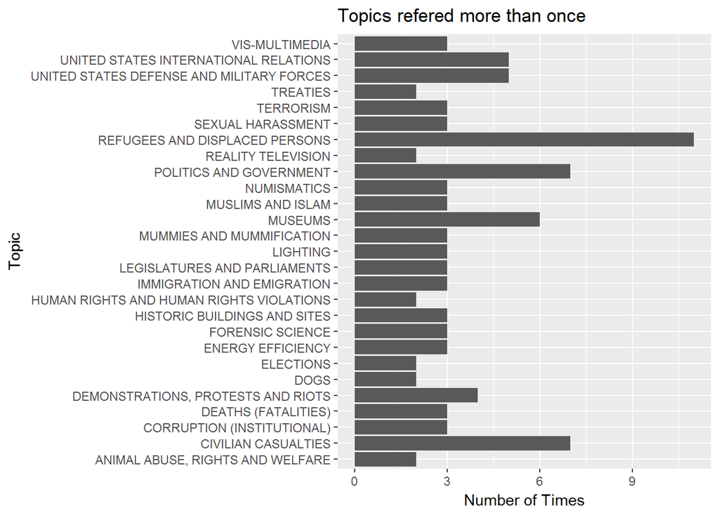

```r
popular.topic <- unlist(mostemailed.data$des_facet)
email.topic <- data.frame(topic=popular.topic, stringsAsFactors = F)

popular.topic <- unlist(mostshared.data$des_facet)
shared.topic <- data.frame(topic=popular.topic, stringsAsFactors = F)

popular.topic <- unlist(mostviewed.data$des_facet)
viewed.topic <- data.frame(topic=popular.topic, stringsAsFactors = F)

mostpopular.topic <- rbind(email.topic, shared.topic, viewed.topic)

popular.topic.summary <- mostpopular.topic %>% group_by(topic) %>% tally() %>% filter(topic != "") %>% arrange(desc(n)) %>% mutate(id=row_number()) %>%  filter(n > 1) %>% select(topic,n)

ggplot(data=popular.topic.summary, aes(x=topic, y=n)) +
  geom_bar(stat="identity") + labs(x="Topic", y="Number of Times", title = "Topics refered more than once") + coord_flip()
```

References: http://developer.nytimes.com